# Instrumental support

# 1 Description of DataSchema variable

The description of harmonised variable is the following:

- Short name: `inst_sup`
- Variable label: `Receives instrumental support (practical help) from people outside the household (relatives/friends/neighbours)?`
- Variable description: `Receives instrumental support (practical help) from people outside the household (relatives/friends/neighbours)?`
- Domain: `Social environment`
- Value type: `categorical`
- Category coding:

| **Code** | **Category Label** |
| --- | --- |
| 0 | No |
| 1 | Yes |

- Category missings:

| **Code** | **Category Label** |
| --- | --- |
| 991 | CAPI/interviewer error |
| 992 | Impute |
| 993 | Disable to measure |
| 994 | Not attempt/not done |
| 995 | Does not answer |
| 996 | Not applicable |
| 997 | Refuse |
| 998 | Do not know |
| 999 | Missing |

# 2 Data process

## 2.1 England

### 2.1.1 Wave 1

#### 2.1.1.1 Study-specific variable description

The study-specific variable elected to be harmonised is:

- Name: `hehpa`
- Label: `Thinking about the activities that you have problems with, does anyone ever help you with these activities (including your partner or other people in your household)?`
- Categories:
  - `1 = Yes`
  - `2 = No`
- Missings:
  - `-9 = Refusal`
  - `-8 = Don't Know`
  - `-1 = Not applicable`
- Description:

HEHPA

| Sample size | Missing values |
| --- | --- |
| 12099 | 5203 |

Category

|  | 1 | 2 |
| --- | --- | --- |
| Frequency | 2765.00 | 4131.00 |
| Percentage | 22.85 | 34.14 |

Type of missing

|  | -9 | -8 | -1 | NA |
| --- | --- | --- | --- | --- |
| Frequency | 0 | 1.00 | 5202 | 0 |
| Percentage | 0 | 0.01 | 43 | 0 |

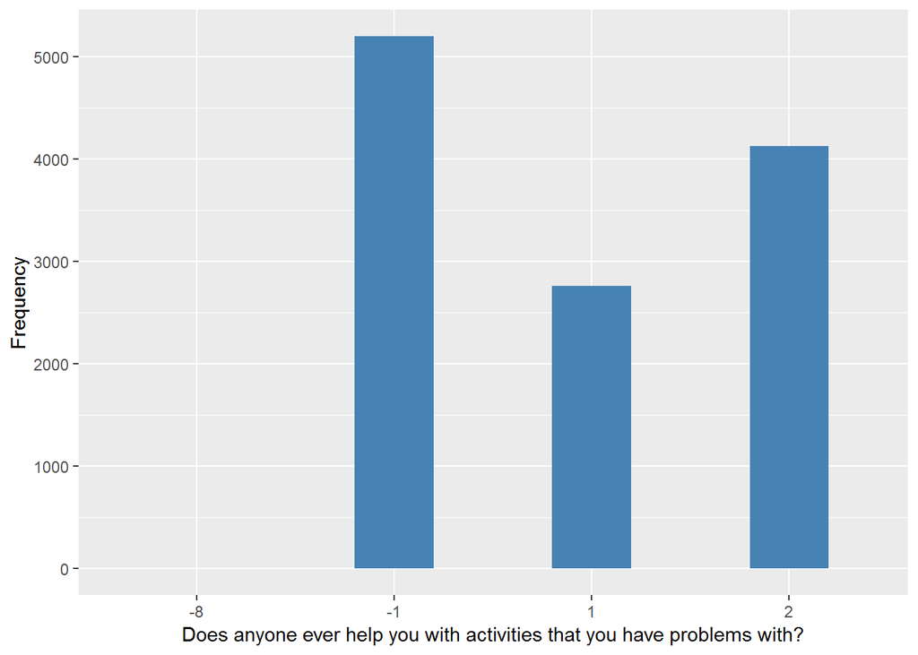

#### 2.1.1.2 Harmonisation algorithm

To compute the harmonize variable from the study-specific variable it has to be recoded as follows:

- `1 into 1`
- `2 into 0`
- `-1 into 996`
- `-8 into 998`
- `-9 into 997`
- `NA into 999`

**R script:**

```r
ELSA_ds_w1 <- tibble(id = ELSA_w1_inst_sup$id)
ELSA_ds_w1$inst_sup <- car::recode(as.vector(ELSA_w1_inst_sup$hehpa), "1='1'; 2='0'; -1='996'; -8='998'; -9='997'; NA='999'")
ELSA_ds_w1$inst_sup <- labelled(ELSA_ds_w1$inst_sup, labels = c(No = 0, Yes = 1,
    Missing = 999, `Do not know` = 998, Refuse = 997, `Not applicable` = 996,
    `Don't answer` = 995, `Not attempt/not done/not yet recorded` = 994, `Disable to measure` = 993,
    Impute = 992, `CAPI/interviewer error` = 991))
```

#### 2.1.1.3 Statistical description of the new harmonised variable

| Sample size | Missing values |
| --- | --- |
| 12099 | 5203 |

Category

|  | 0 | 1 |
| --- | --- | --- |
| Frequency | 4131.00 | 2765.00 |
| Percentage | 34.14 | 22.85 |

Type of missing

|  | 991 | 992 | 993 | 994 | 995 | 996 | 997 | 998 | 999 | NA |
| --- | --- | --- | --- | --- | --- | --- | --- | --- | --- | --- |
| Frequency | 0 | 0 | 0 | 0 | 0 | 5202 | 0 | 1.00 | 0 | 0 |
| Percentage | 0 | 0 | 0 | 0 | 0 | 43 | 0 | 0.01 | 0 | 0 |

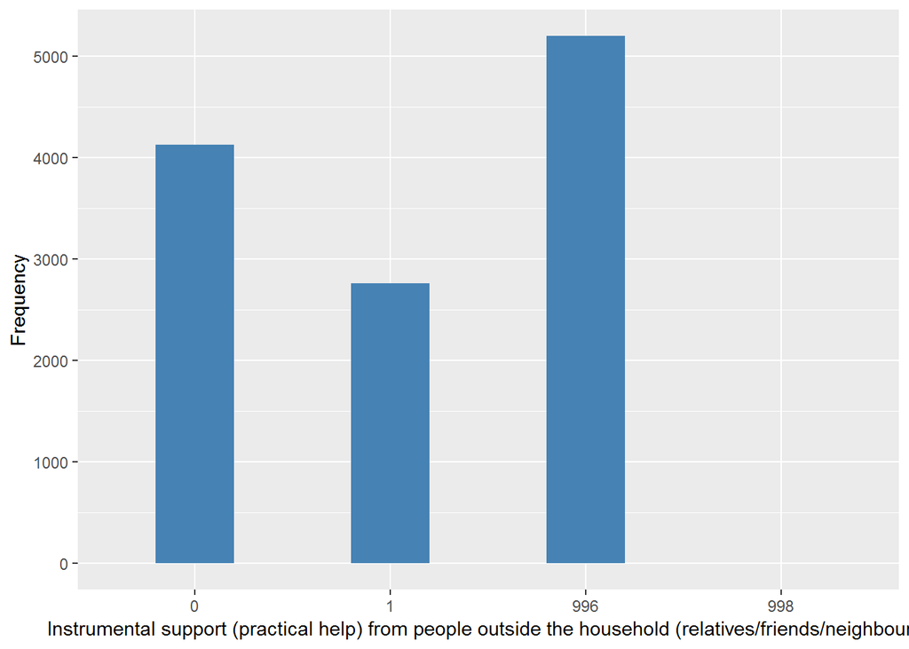

#### 2.1.1.4 Validation

|  | 2->0 | 1->1 | -1->996 | -8->998 |
| --- | --- | --- | --- | --- |
| BeforeH | 4131 | 2765 | 5202 | 1 |
| AfterH | 4131 | 2765 | 5202 | 1 |

### 2.1.2 Wave 2

Not found.

### 2.1.3 Wave 3

Not found.

### 2.1.4 Wave 4

Not found.

### 2.1.5 Wave 5

Not found.

### 2.1.6 Wave 6

Not found.

### 2.1.7 Wave 7

Not found.

# 3 Quality estimation